# Data Engineering PFS

Dr. Immanuel Williams

9/26/2019

# MUST THINK ABOout : change from pre to post in postive direction

# MUST THINK ABOout : Summarize Data

# MUST THINK ABOout : run analysis on

# MUST THINK ABOout : state original questions

## Introduction

Data is coming from three sources

1. Pre-Survey
2. Post-Survey
3. Activity

## Cleaning Data

### Issues with cleaning Data

0. No Modifications were added to the csv files
1. Step Change Column Names
2. Duplicate Ids (7-333,2-222)
3. Change Ids in which they occurr at different class (5-555)

## Join Pre Post Survey Data

### Issues with Joining

No Issues

## Summary

|  | No | Yes |
| --- | --- | --- |
| No | 39 | 2 |
| Yes | 31 | 54 |

<sup>1</sup> Rows are Interested in Sports  
<sup>2</sup> Columns are Follows Basketball

## Analysis

### Main Questions

1. Did opinions change of the GOAT? (do test by class as well)
2. Did opinions change about Kobe Change? (do test by class as well)
3. Did feeling of statistics change? (do test by class as well)

3a. Of those that like BBall or follow sports did PFS change your feelings of statistics?

3b. Of those that do not like BBall or follow sports did PFS change your feelings of statistics?

4. Did understanding of statistics change? (do test by class as well)

4a. Of those that like BBall or follow sports did PFS change your understandings of statistics?

4b. Of those that do not like BBall or follow sports did PFS change your understandings of statistics?

5. Did feelings of data visualizations change? (do test by class as well)

5a. Of those that like BBall or follow sports did PFS change your feelings of data visualizations?

5b. Of those that do not like BBall or follow sports did PFS change your feelings of data visualizations?

6. Did understanding of data visualizations change? (do test by class as well)

6a. Of those that like BBall or follow sports did PFS change your understandings of data visualizations?

6b. Of those that do not like BBall or follow sports did PFS change your understandings of data visualizations?

7. Does gender and Sports have a relationship?
8. Does gender and follow basketball have a relationship?

### Questions **NOT** answered graphically

- Activity change perception about players?
- Word Selection (Look for statistical words)?
- How did they defend their answers?

#### *1. Did opinions change of the GOAT? (do test by class as well)*

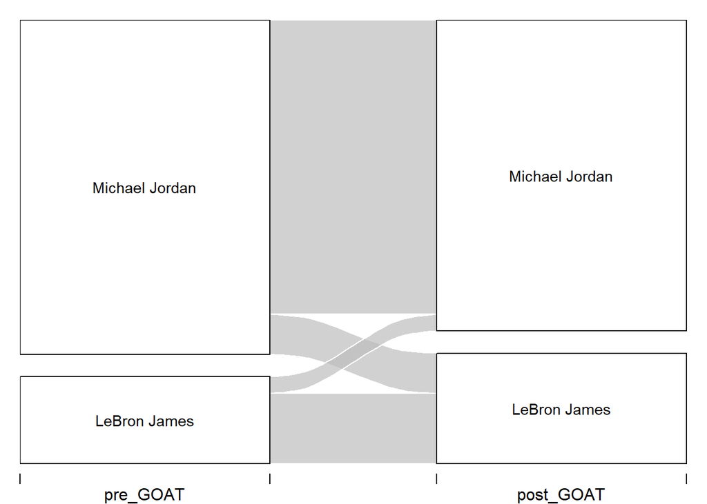

|  | post_GOAT | pre_GOAT |
| --- | --- | --- |
| LeBron James | 33 | 26 |
| Michael Jordan | 93 | 100 |

```
##
##  Pearson's Chi-squared test with Yates' continuity correction
##
## data:  .
## X-squared = 0.7967, df = 1, p-value = 0.3721
```

We were able to see some change in opinion about who is the GOAT but not enough to be statistically significant.

#### *2. Did opinions change about Kobe Change? (do test by class as well)*

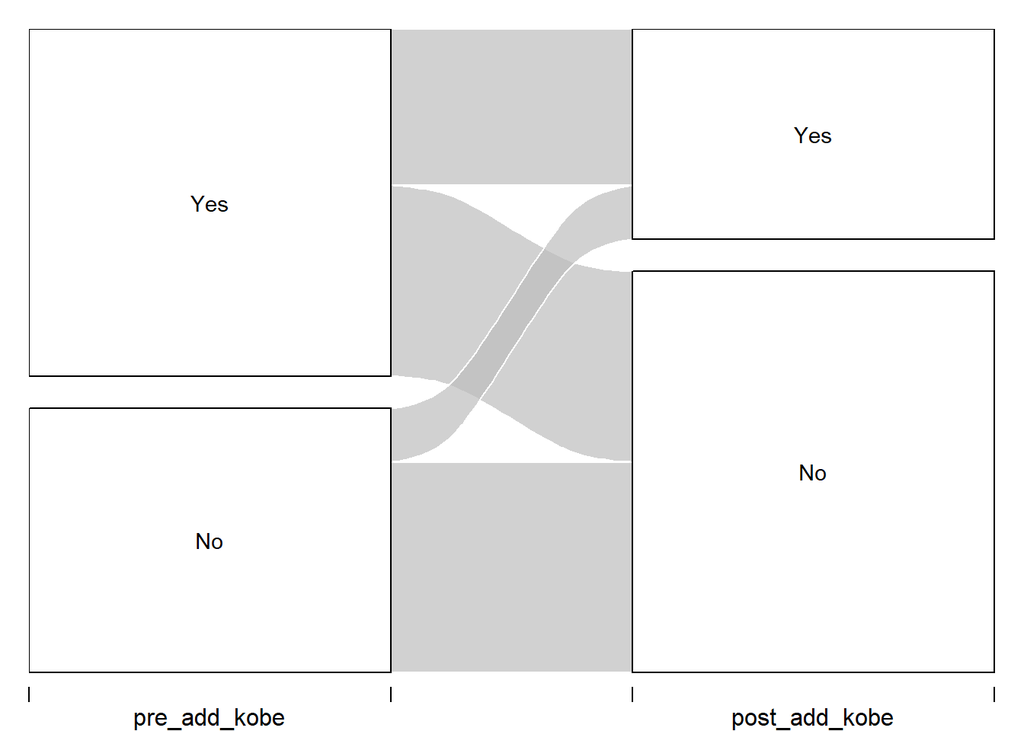

|  | post_add_kobe | pre_add_kobe |
| --- | --- | --- |
| No | 82 | 54 |
| Yes | 44 | 71 |

```
##
##  Pearson's Chi-squared test with Yates' continuity correction
##
## data:  .
## X-squared = 11.235, df = 1, p-value = 0.0008028
```

We were able to see a change in opinion about whether Kobe should be added to this discussion of who is the GOAT after the activity. We were also able to reject the null hypothesis that there is no relationship between time (pre and post) and opinion about Kobe implying that Plots for Shots had an impact on students opinion on Kobe. Based on the graph it is conclusive that students went from saying yes he should to no he should not be added.

#### *3. Did feeling of statistics change? (do test by class as well)*

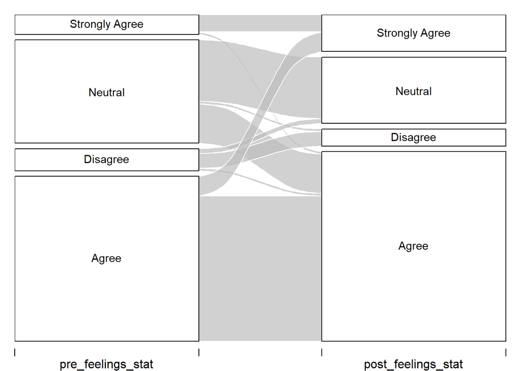

##### *3a. Of those that like BBall or follow sports did PFS change your feelings of statistics?*

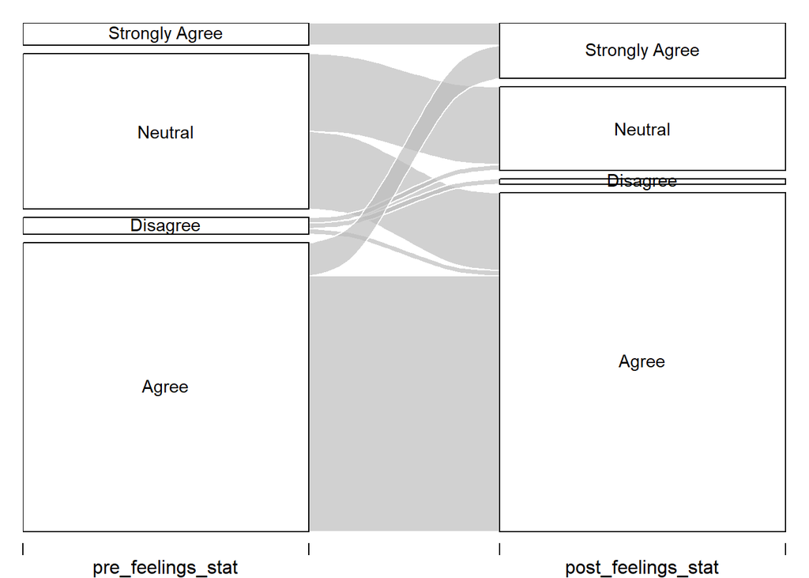

##### *3b. Of those that do not like BBall or follow sports did PFS change your feelings of statistics?*

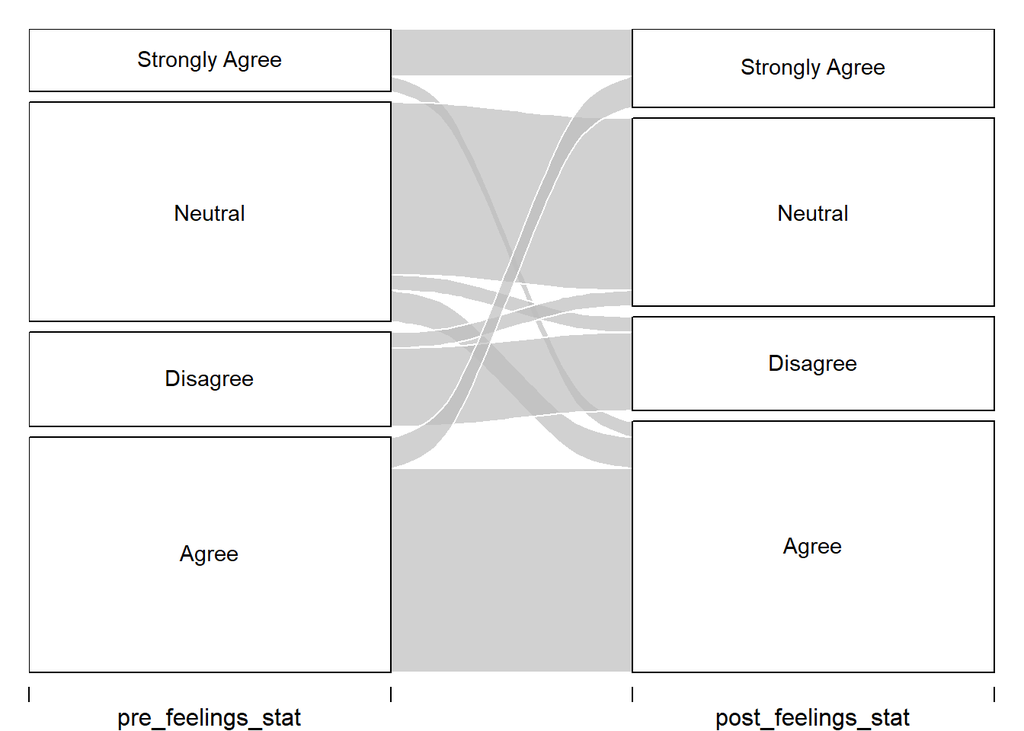

#### *4. Did understanding of statistics change? (do test by class as well)*

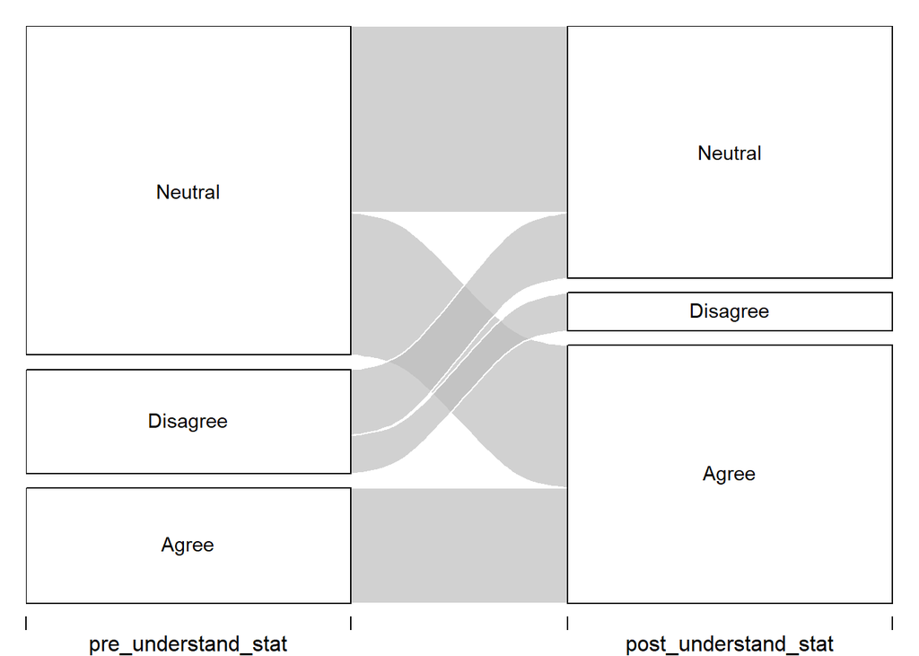

##### *4a. Of those that like BBall or follow sports did PFS change your understandings of statistics?*

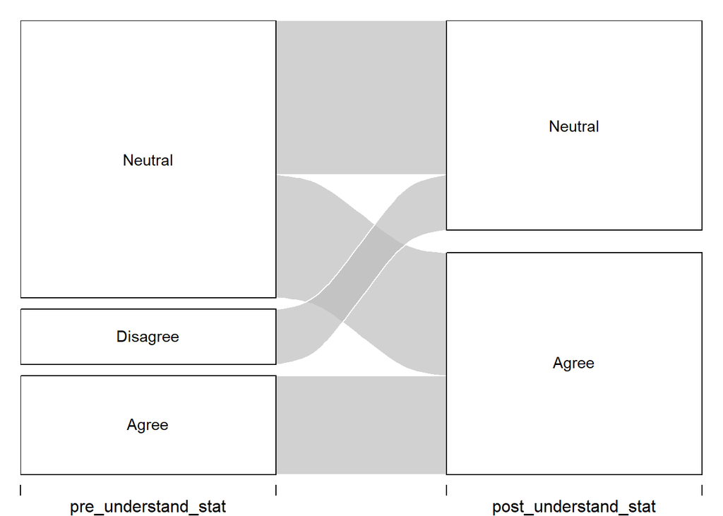

##### *4b. Of those that do not like BBall or follow sports did PFS change your understandings of statistics?*

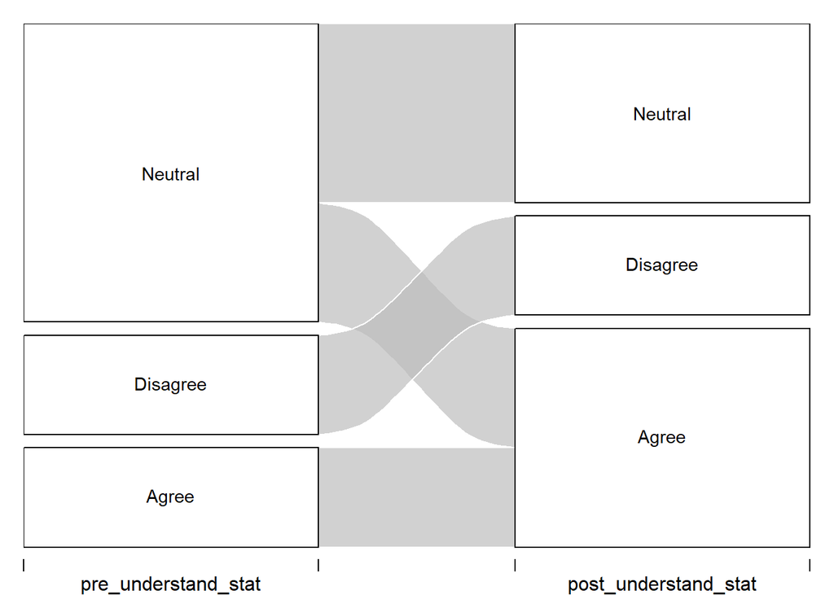

#### *5. Did feeling of data visualizations change? (do test by class as well)*

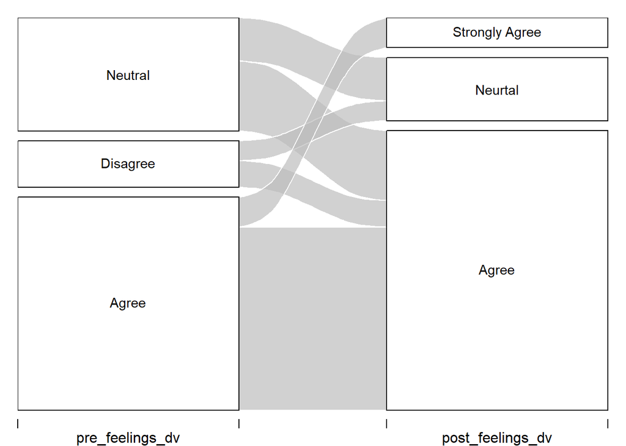

##### *5a. Of those that like BBall or follow sports did PFS change your feelings of data visualizations?*

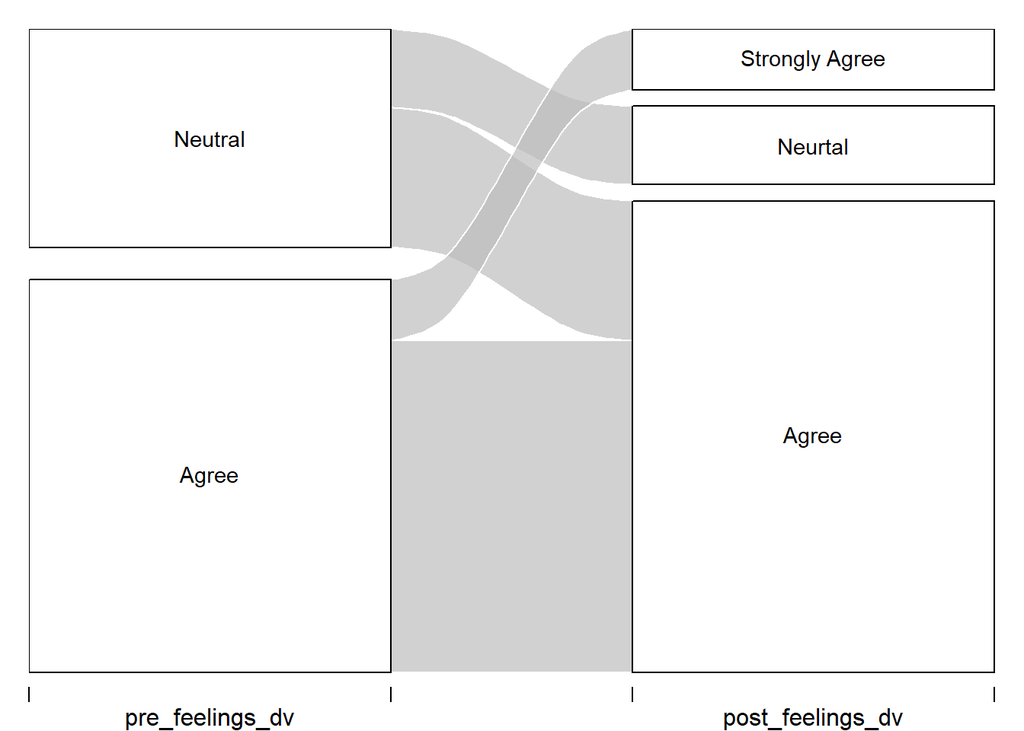

##### *5b. Of those that do not like BBall or follow sports did PFS change your feelings of data visualizations?*

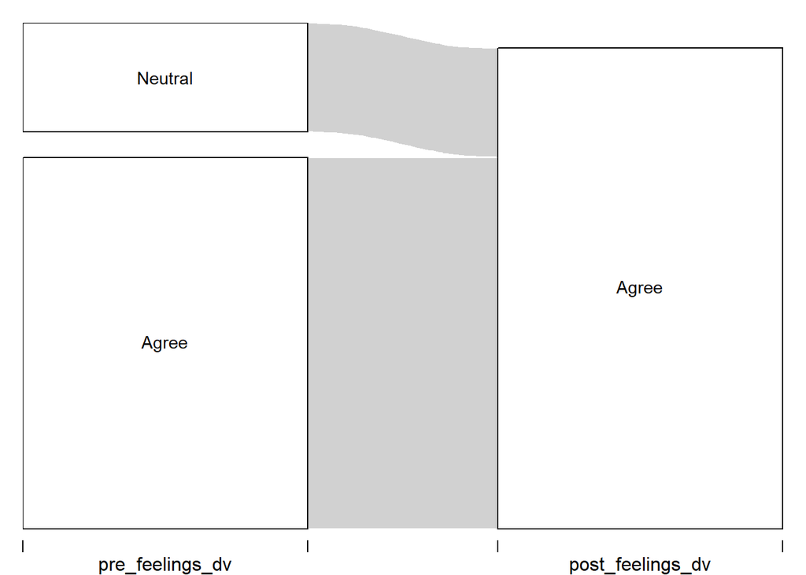

#### *6. Did understanding of data visualizations change? (do test by class as well)*

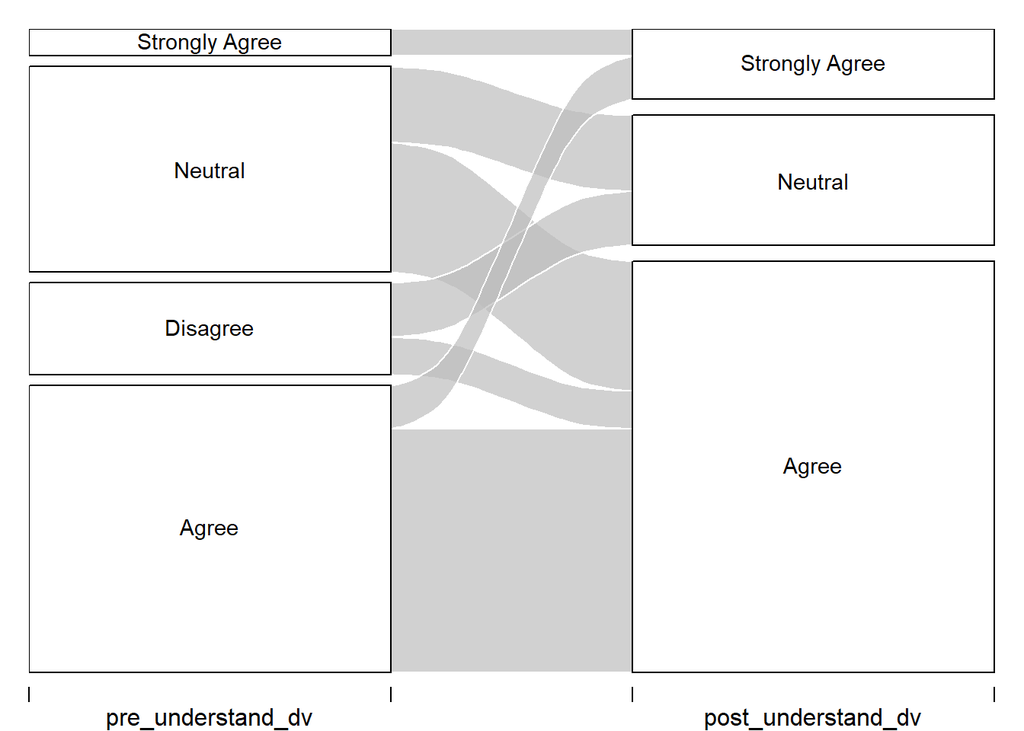

##### *6a. Of those that like BBall or follow sports did PFS change your understandings of data visualizations?*

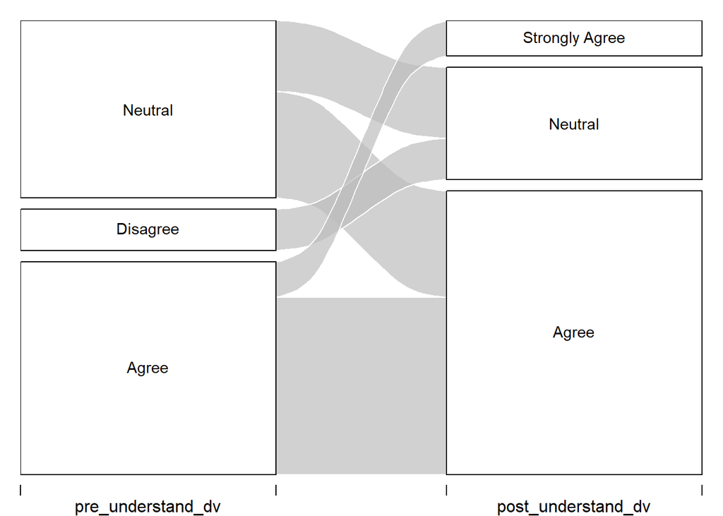

##### *6b. Of those that do not like BBall or follow sports did PFS change your understandings of data visualizations?*

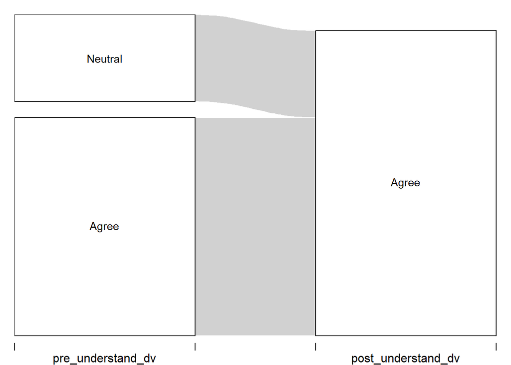

#### *7. Does gender and Sports have a relationship?*

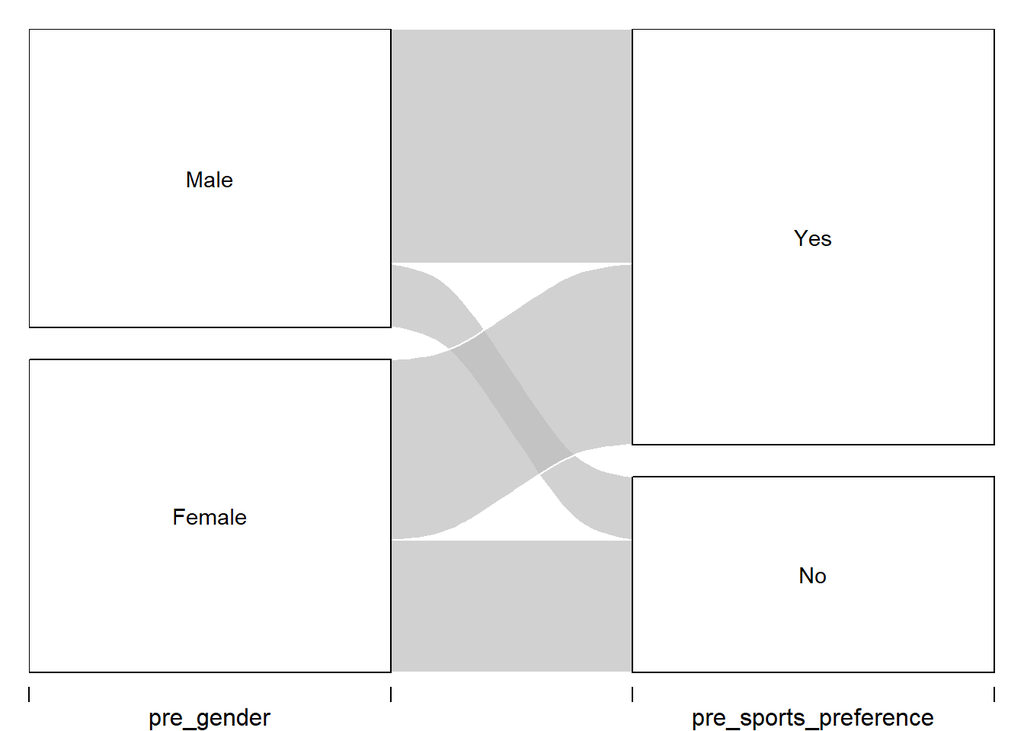

#### *8. Does gender and follow basketball have a relationship?*

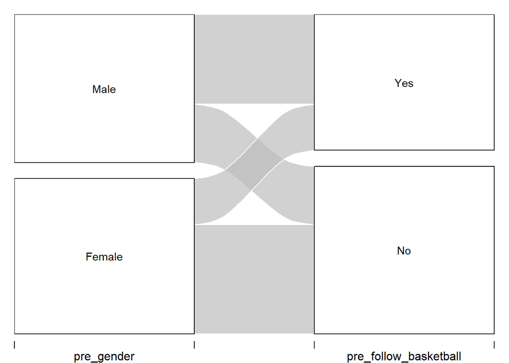